Started Dec 7,2016

# Machine Learning Engineer Nanodegree

## Project: Creating Customer Segments

Reviewer3: https://customers.microsoft.com/en-us/story/food-delivery-service-uses-machine-learning-to-revolut

Reviewer4: For more insights into performing cluster analysis with our wholesale customer dataset,

https://arxiv.org/abs/1211.0437

Welcome to the third project of the Machine Learning Engineer Nanodegree! In this notebook, some template code has already been provided for you, and it will be your job to implement the additional functionality necessary to successfully complete this project. Sections that begin with **'Implementation'** in the header indicate that the following block of code will require additional functionality which you must provide. Instructions will be provided for each section and the specifics of the implementation are marked in the code block with a `'TODO'` statement. Please be sure to read the instructions carefully!

In addition to implementing code, there will be questions that you must answer which relate to the project and your implementation. Each section where you will answer a question is preceded by a **'Question X'** header. Carefully read each question and provide thorough answers in the following text boxes that begin with **'Answer:'**. Your project submission will be evaluated based on your answers to each of the questions and the implementation you provide.

> **Note:** Code and Markdown cells can be executed using the **Shift + Enter** keyboard shortcut. In addition, Markdown cells can be edited by typically double-clicking the cell to enter edit mode.

## Getting Started

In this project, you will analyze a dataset containing data on various customers' annual spending amounts (reported in *monetary units*) of diverse product categories for internal structure. One goal of this project is to best describe the variation in the different types of customers that a wholesale distributor interacts with. Doing so would equip the distributor with insight into how to best structure their delivery service to meet the needs of each customer.

The dataset for this project can be found on the [UCI Machine Learning Repository](https://archive.ics.uci.edu/ml/datasets/Wholesale+customers). For the purposes of this project, the features `'Channel'` and `'Region'` will be excluded in the analysis — with focus instead on the six product categories recorded for customers.

Run the code block below to load the wholesale customers dataset, along with a few of the necessary Python libraries required for this project. You will know the dataset loaded successfully if the size of the dataset is reported.

```python
import os
print os.getcwd()
```

```
/Users/parksoy/Desktop/GoogleDrive_Soyoung/Udacity_nanoDegree_MachineLearning/customer_segments
```

```python
# Import libraries necessary for this project
import numpy as np
import pandas as pd
from IPython.display import display # Allows the use of display() for DataFrames

# Import supplementary visualizations code visuals.py
import visuals as vs

# Pretty display for notebooks
%matplotlib inline

# Load the wholesale customers dataset
try:
    data = pd.read_csv("customers.csv")
    data.drop(['Region', 'Channel'], axis = 1, inplace = True)
    print "Wholesale customers dataset has {} samples with {} features each.".format(*data.shape)
except:
    print "Dataset could not be loaded. Is the dataset missing?"
```

```
Wholesale customers dataset has 440 samples with 6 features each.
```

```python
data.to_csv('originaldata.csv')
```

## Data Exploration

In this section, you will begin exploring the data through visualizations and code to understand how each feature is related to the others. You will observe a statistical description of the dataset, consider the relevance of each feature, and select a few sample data points from the dataset which you will track through the course of this project.

Run the code block below to observe a statistical description of the dataset. Note that the dataset is composed of six important product categories: **'Fresh'**, **'Milk'**, **'Grocery'**, **'Frozen'**, **'Detergents_Paper'**, and **'Delicatessen'**. Consider what each category represents in terms of products you could purchase.

```python
# Display a description of the dataset
display(data.describe())
```

|  | Fresh | Milk | Grocery | Frozen | Detergents_Paper | Delicatessen |
| --- | --- | --- | --- | --- | --- | --- |
| count | 440.000000 | 440.000000 | 440.000000 | 440.000000 | 440.000000 | 440.000000 |
| mean | 12000.297727 | 5796.265909 | 7951.277273 | 3071.931818 | 2881.493182 | 1524.870455 |
| std | 12647.328865 | 7380.377175 | 9503.162829 | 4854.673333 | 4767.854448 | 2820.105937 |
| min | 3.000000 | 55.000000 | 3.000000 | 25.000000 | 3.000000 | 3.000000 |
| 25% | 3127.750000 | 1533.000000 | 2153.000000 | 742.250000 | 256.750000 | 408.250000 |
| 50% | 8504.000000 | 3627.000000 | 4755.500000 | 1526.000000 | 816.500000 | 965.500000 |
| 75% | 16933.750000 | 7190.250000 | 10655.750000 | 3554.250000 | 3922.000000 | 1820.250000 |
| max | 112151.000000 | 73498.000000 | 92780.000000 | 60869.000000 | 40827.000000 | 47943.000000 |

```python
data.head(2)
```

|  | Fresh | Milk | Grocery | Frozen | Detergents_Paper | Delicatessen |
| --- | --- | --- | --- | --- | --- | --- |
| 0 | 12669 | 9656 | 7561 | 214 | 2674 | 1338 |
| 1 | 7057 | 9810 | 9568 | 1762 | 3293 | 1776 |

### Implementation: Selecting Samples

To get a better understanding of the customers and how their data will transform through the analysis, it would be best to select a few sample data points and explore them in more detail. In the code block below, add **three** indices of your choice to the `indices` list which will represent the customers to track. It is suggested to try different sets of samples until you obtain customers that vary significantly from one another.

```python
# TODO: Select three indices of your choice you wish to sample from the dataset
indices = [0,1,10]

# Create a DataFrame of the chosen samples
samples = pd.DataFrame(data.loc[indices], columns = data.keys()).reset_index(drop = True)
print "(total N of samples)",len(data)
print "Chosen samples of wholesale customers dataset:"

display(samples)
```

```
(total N of samples) 440
Chosen samples of wholesale customers dataset:
```

|  | Fresh | Milk | Grocery | Frozen | Detergents_Paper | Delicatessen |
| --- | --- | --- | --- | --- | --- | --- |
| 0 | 12669 | 9656 | 7561 | 214 | 2674 | 1338 |
| 1 | 7057 | 9810 | 9568 | 1762 | 3293 | 1776 |
| 2 | 3366 | 5403 | 12974 | 4400 | 5977 | 1744 |

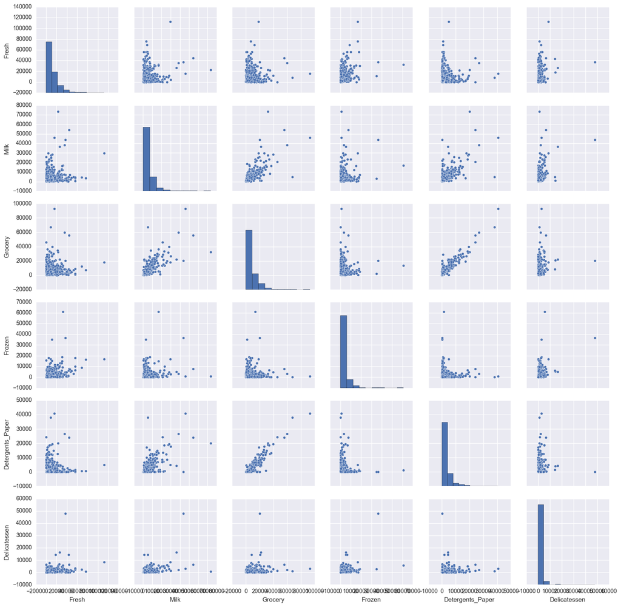

```python
#EDA1
import seaborn as sns
sns.pairplot(data=data, dropna=True)
```

```python
#EDA2
#sns.set(style="whitegrid", color_codes=True)
#sns.factorplot("Detergents_Paper", col="Grocery", data=data,  kind="count") #hue='income',col_wrap=3
```

### Question 1

Consider the total purchase cost of each product category and the statistical description of the dataset above for your sample customers.  
*What kind of establishment (customer) could each of the three samples you've chosen represent?*  
**Hint:** Examples of establishments include places like markets, cafes, and retailers, among many others. Avoid using names for establishments, such as saying *"McDonalds"* when describing a sample customer as a restaurant.

|  | Fresh | Milk | Grocery | Frozen | Detergents_Paper | Delicatessen |
| --- | --- | --- | --- | --- | --- | --- |
| 0 | 12669 | 9656 | 7561 | 214 | 2674 | 1338 |
| 1 | 7057 | 9810 | 9568 | 1762 | 3293 | 1776 |
| 2 | 3366 | 5403 | 12974 | 4400 | 5977 | 1744 |

|  | Fresh | Milk | Grocery | Frozen | Detergents_Paper | Delicatessen |
| --- | --- | --- | --- | --- | --- | --- |
| 0 | 4165.0 | 6029.0 | 2805.0 | -1312.0 | 1858.0 | 372.0 |
| 1 | -1447.0 | 6183.0 | 4812.0 | 236.0 | 2477.0 | 810.0 |
| 2 | -5138.0 | 1776.0 | 8218.0 | 2874.0 | 5161.0 | 778.0 |

```
    Fresh  Milk  Grocery  Frozen  Detergents_Paper  Delicatessen
0    66.4  83.9     65.0     7.5              68.2          63.0
1    44.1  84.8     71.8    54.5              70.5          74.1
10   26.9  64.5     82.0    79.5              84.3          73.2
```

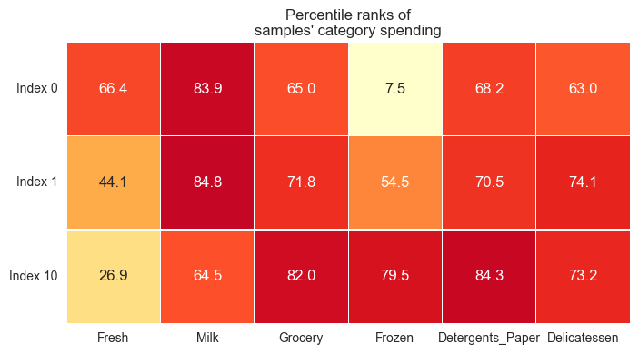

```python
#Reviewer2 suggested to compare with the mean / median / quartiles.

display(samples)
display(samples - np.round(data.median()))


#display(samples - np.round(data.mean()))
#display(samples - np.round(np.percentile(data, 50,axis=0)))
#print np.percentile(data, 75,axis=0)

#Reviewer3 suggests to look using heatmap.
#http://seaborn.pydata.org/generated/seaborn.heatmap.html
import matplotlib.pyplot as plt
import seaborn as sns

# look at percentile ranks
pcts = 100. * data.rank(axis=0, pct=True).iloc[indices].round(decimals=3)
print pcts

# visualize percentiles with heatmap
sns.heatmap(pcts, annot=True, linewidth=.1, vmax=99, fmt='.1f', cmap='YlOrRd', square=True, cbar=False)
plt.yticks([2.5,1.5,.5], ['Index '+str(x) for x in indices], rotation='horizontal')
plt.title('Percentile ranks of\nsamples\' category spending');
```

**Answer:**

# Original answer:

customer  
0 Fresh/milk/grocery in order are used in majority. ==> Restaurant that uses fresh to cook.  
1 Milk/Grocery/Fresh in order are used in majority. ==> Restaurant that uses milk mainly.  
2 Grocery is dominantly used. ==> Retailers that sell grocery.

# Reviewer2 suggests to compare with the descriptive stats of dataset:

customer  
0 Milk/Fresh/Grocery is significantly more purchased used than median. ==> Possibly Restaurant that uses fresh to cook.  
1 Milk/Grocery/Detergents_Paper is significantly more purchased used than median. Fresh is purchased less than median. ==> Restaurant that uses milk mainly.  
2 Grocery/Detergents_Paper is dominantly used. Fresh was purchased less than median. ==> Retailers that sell grocery.

### Implementation: Feature Relevance

One interesting thought to consider is if one (or more) of the six product categories is actually relevant for understanding customer purchasing. That is to say, is it possible to determine whether customers purchasing some amount of one category of products will necessarily purchase some proportional amount of another category of products? We can make this determination quite easily by training a supervised regression learner on a subset of the data with one feature removed, and then score how well that model can predict the removed feature.

In the code block below, you will need to implement the following:

- Assign `new_data` a copy of the data by removing a feature of your choice using the `DataFrame.drop` function.
- Use `sklearn.cross_validation.train_test_split` to split the dataset into training and testing sets.
  - Use the removed feature as your target label. Set a `test_size` of `0.25` and set a `random_state`.
- Import a decision tree regressor, set a `random_state`, and fit the learner to the training data.
- Report the prediction score of the testing set using the regressor's `score` function.

  Reviewer4 added:Detecting redundant features is a common step during feature selection.

  An Introduction to Feature Selection

  http://machinelearningmastery.com/an-introduction-to-feature-selection/

```python
# TODO: Make a copy of the DataFrame, using the 'drop' function to drop the given feature
item='Detergents_Paper' #Fresh,Milk,Grocery,Frozen,Detergents_Paper,Delicatessen
target=data[item]
new_data = data.drop(item,axis=1)

# TODO: Split the data into training and testing sets using the given feature as the target
from sklearn.model_selection import train_test_split #cross_validation
X_train, X_test, y_train, y_test = train_test_split(new_data, target, test_size = 0.25, random_state = 42)

# TODO: Create a decision tree regressor and fit it to the training set
from sklearn import tree
#from sklearn.naive_bayes import GaussianNB

#Reviewer2 caught the mistake: should not use "DecisionTreeClassifier".
regressor1= tree.DecisionTreeRegressor() #random_state=42 can be added
#regressor2=GaussianNB()
regressor1=regressor1.fit(X_train, y_train)
predictions_test= regressor1.predict(X_test)

# TODO: Report the score of the prediction using the testing set
from sklearn.metrics import accuracy_score
from sklearn.metrics import r2_score

#Reviewer3 pointed metrics.accuracy_score and metrics.r2_score that
#the true labels should be the first parameter passed to the method,
#not the predictions...

#train_score_accuracy = accuracy_score(regressor1.predict(X_train) , y_train)# predictions_test, y_test
train_score_accuracy = accuracy_score(y_train,regressor1.predict(X_train))
print "train_Score_accuracy:",train_score_accuracy

#test_score_accuracy = accuracy_score(regressor1.predict(X_test) , y_test)
test_score_accuracy = accuracy_score(y_test,regressor1.predict(X_test))
print "test_Score_accuracy:",test_score_accuracy

#train_score_r2 = r2_score(regressor1.predict(X_train) , y_train)
train_score_r2 = r2_score(y_train,regressor1.predict(X_train))
print "train_Score_r2:",train_score_r2

#test_score_r2 = r2_score(regressor1.predict(X_test) , y_test)
test_score_r2 = r2_score(y_test,regressor1.predict(X_test))
print "test_Score_r2:",test_score_r2


#Reviewer3 added another way of simplifying the implementation of
#score instead of using imported method.

# Report the score of the prediction using the testing set
score_direct = regressor1.score(X_test, y_test)
print "Direct way of seeing test score:", score_direct
```

```
train_Score_accuracy: 1.0
test_Score_accuracy: 0.0
train_Score_r2: 1.0
test_Score_r2: 0.363387470627
Direct way of seeing test score: 0.363387470627
```

```python
print type(X_train)
print type(y_train)
```

```
<class 'pandas.core.frame.DataFrame'>
<class 'pandas.core.series.Series'>
```

### Question 2

*Which feature did you attempt to predict? What was the reported prediction score? Is this feature is necessary for identifying customers' spending habits?*  
**Hint:** The coefficient of determination, `R^2`, is scored between 0 and 1, with 1 being a perfect fit. A negative `R^2` implies the model fails to fit the data.

**Answer:**

**#Original answer**

Detergents_Paper was attempted to be predicted. Accuracy is 1 for trainset, 0 for testset. Coefficient of determination (r^2)is 1 for training set, 0.21 for test set, which can be interpreted as failed to fit to the test data. The Detergents_Paper seems not a good feature to identify customer's speding habit.

**#Reviewer2 caught the wrong regressor, and now I fixed and re-ran.**

ntrain_Score_accuracy: 1.0  
ntest_Score_accuracy: 0.0  
ntrain_Score_r2: 1.0  
ntest_Score_r2: 0.487937295158

Detergents_Paper was attempted to be predicted. Accuracy is 1 for trainset, 0 for testset. However, coefficient of determination (r^2) is 1 for training set, 0.49 for test set, which can be interpreted as well correlated to the rest of the dataset. The Detergents_Paper seems not a good feature to identify customer's spending habit since the customer would purchase other products along with Detergents_Paper.

**#Reviewer3 pointed metrics.accuracy_score and metrics.r2_score that the true labels should be the first parameter passed to the method, not the predictions...**  
http://scikit-learn.org/stable/modules/generated/sklearn.metrics.r2_score.html

So I fixed the order of input parameters passed to the method, and I get slightly different number in test_Score_r2.

train_Score_accuracy: 1.0 test_Score_accuracy: 0.0 train_Score_r2: 1.0 test_Score_r2: 0.363387470627 Direct way of seeing test score: 0.363387470627

**#Reviewer 4 added chi square test to check the normality**

http://stackoverflow.com/questions/12838993/scipy-normaltest-how-is-it-used

*Normaltest returns a 2-tuple of the chi-squared statistic, and the associated p-value. Given the null hypothesis that x came from a normal distribution, the p-value represents the probability that a chi-squared statistic that large (or larger) would be seen.

If the p-val is very small, it means it is unlikely that the data came from a normal distribution. *

**#Reviewer 4 added Issues with the chi square test**

http://stats.stackexchange.com/questions/2492/is-normality-testing-essentially-useless

```python
from scipy import stats
feature = data['Fresh']
norm_results = stats.normaltest(feature, axis=0)

# low p-value indicates data not likely to come from normal distribution
print norm_results
```

```
NormaltestResult(statistic=274.34162662040899, pvalue=2.6759173855882678e-60)
```

### Visualize Feature Distributions

To get a better understanding of the dataset, we can construct a scatter matrix of each of the six product features present in the data. If you found that the feature you attempted to predict above is relevant for identifying a specific customer, then the scatter matrix below may not show any correlation between that feature and the others. Conversely, if you believe that feature is not relevant for identifying a specific customer, the scatter matrix might show a correlation between that feature and another feature in the data. Run the code block below to produce a scatter matrix.

```
type of data: <class 'pandas.core.frame.DataFrame'>
```

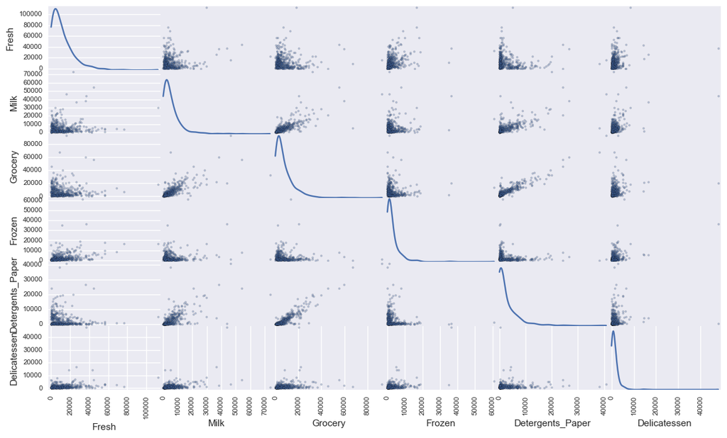

```python
# Produce a scatter matrix for each pair of features in the data
print "type of data:", type(data)
pd.scatter_matrix(data, alpha = 0.3, figsize = (14,8), diagonal = 'kde');
```

### Question 3

*Are there any pairs of features which exhibit some degree of correlation? Does this confirm or deny your suspicions about the relevance of the feature you attempted to predict? How is the data for those features distributed?*  
**Hint:** Is the data normally distributed? Where do most of the data points lie?

**ORIGINAL Answer:**

Yes, there are pairs of features with some degree of correlation-

Detergents_Paper-Grocery,  
Grocery-Milk,  
Detergents_Paper-Milk

pairs look somewhat correlated. My suspicion about Detergent_Paper-Grocery was confirmed to relevent, however, the prediction based on tree didn't show the same conclusion. The data is not normally distrubited, it is right skewed-most of the dataset lie on low numbers(monetary unit).This may be the reason why the original dataset might have not been well modeled with tree based regressor.

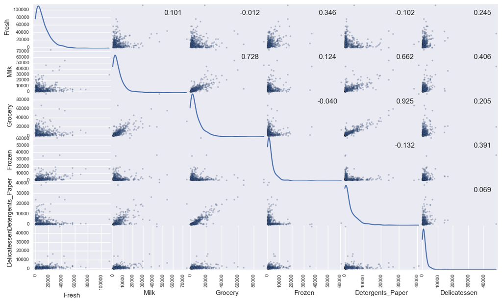

```python
#Reviewer2 suggests to look numerical correlation:

axes = pd.scatter_matrix(data, alpha = 0.3, figsize = (14,8), diagonal = 'kde')
corr = data.corr().as_matrix()
for i, j in zip(*np.triu_indices_from(axes, k=1)):
    axes[i, j].annotate("%.3f" %corr[i,j], (0.8, 0.8), xycoords='axes fraction', ha='center', va='center')
```

```python
#Reviewer2 suggests to check mean and median for skewness of distribution.
display(np.round(data.mean()) - np.round(data.median()))
```

```
Fresh               3496.0
Milk                2169.0
Grocery             3195.0
Frozen              1546.0
Detergents_Paper    2065.0
Delicatessen         559.0
dtype: float64
```

**REVISED Answer:**

# Revised answer based on reviewer2's comment:

Yes, there are pairs of features with some degree of correlation-

Detergents_Paper-Grocery(0.925),  
Grocery-Milk(0.728),  
Detergents_Paper-Milk(0.662)

My suspicion about relevance of Detergents_Paper-Grocery is confirmed by high correlation number.

Looking at relative location of mean and median, the data of each item is right skewed-most of the dataset lie on low numbers(monetary unit) and mean is higher than median.

# Reviewer3 added

http://www.mathsisfun.com/data/skewness.html  
http://mathworld.wolfram.com/LogNormalDistribution.html

## Data Preprocessing

In this section, you will preprocess the data to create a better representation of customers by performing a scaling on the data and detecting (and optionally removing) outliers. Preprocessing data is often times a critical step in assuring that results you obtain from your analysis are significant and meaningful.

### Implementation: Feature Scaling

If data is not normally distributed, especially if the mean and median vary significantly (indicating a large skew), it is most [often appropriate](http://econbrowser.com/archives/2014/02/use-of-logarithms-in-economics) to apply a non-linear scaling — particularly for financial data. One way to achieve this scaling is by using a [Box-Cox test](http://scipy.github.io/devdocs/generated/scipy.stats.boxcox.html), which calculates the best power transformation of the data that reduces skewness. A simpler approach which can work in most cases would be applying the natural logarithm.

# Reviewer3 added when to apply scaling:

http://stats.stackexchange.com/questions/121886/when-should-i-apply-feature-scaling-for-my-data

In the code block below, you will need to implement the following:

- Assign a copy of the data to `log_data` after applying logarithmic scaling. Use the `np.log` function for this.
- Assign a copy of the sample data to `log_samples` after applying logarithmic scaling. Again, use `np.log`.

```python
print type(data)
print type(data.values)
print "\n"
print data.values
print "\n"
print np.log(data.values)
```

```
<class 'pandas.core.frame.DataFrame'>
<type 'numpy.ndarray'>


[[12669  9656  7561   214  2674  1338]
 [ 7057  9810  9568  1762  3293  1776]
 [ 6353  8808  7684  2405  3516  7844]
 ...,
 [14531 15488 30243   437 14841  1867]
 [10290  1981  2232  1038   168  2125]
 [ 2787  1698  2510    65   477    52]]


[[  9.44691334   9.17533476   8.93075874   5.36597602   7.89133076
    7.19893124]
 [  8.86177531   9.19115755   9.16617948   7.47420481   8.09955428
    7.48211892]
 [  8.75668242   9.08341568   8.94689552   7.78530518   8.16507926
    8.96750419]
 ...,
 [  9.58403958   9.64782081  10.31702003   6.0799332    9.6051489
    7.53208814]
 [  9.23892783   7.59135705   7.71065332   6.94505106   5.12396398
    7.66152708]
 [  7.93272103   7.43720637   7.82803803   4.17438727   6.16751649
    3.95124372]]
```

```
log_data: <type 'numpy.ndarray'>
log_data_pddf: <class 'pandas.core.frame.DataFrame'>
log_samples:       Fresh      Milk   Grocery    Frozen  Detergents_Paper  Delicatessen
0  9.446913  9.175335  8.930759  5.365976          7.891331      7.198931
1  8.861775  9.191158  9.166179  7.474205          8.099554      7.482119
2  8.121480  8.594710  9.470703  8.389360          8.695674      7.463937
```

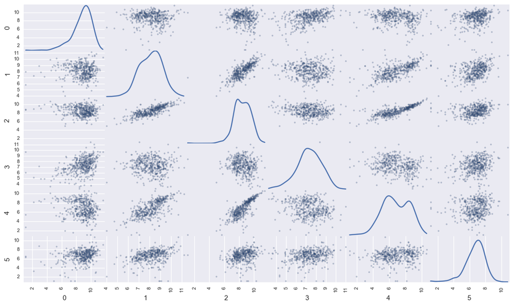

```python
# TODO: Scale the data using the natural logarithm
log_data = np.log(data.values)
print "log_data:",type(log_data)
log_data_pddf=pd.DataFrame(log_data)
print "log_data_pddf:",type(log_data_pddf)

# TODO: Scale the sample data using the natural logarithm
#Reviewer1 suggests to choose 3, not 5. However, I would like to see two different categories of customer, so I didnt fix it.
#log_samples = log_data[:5]
#reviewer2 point I need to use previously chosen samples.

log_samples = np.log(samples)
print "log_samples:", log_samples

# Produce a scatter matrix for each pair of newly-transformed features
pd.scatter_matrix(log_data_pddf, alpha = 0.3, figsize = (14,8), diagonal = 'kde');
```

**Question to reviewer2:**

Q: I would like to learn how to randomly sample including two different segments effectively, instead of pointing I choose 5, instead of 3 items.

A: We can't really do this, as we don't have the cluster assignments at this point in the project. You could look into choosing data points(such as one with high Grocery, Milk and Deter spending and another with low amounts in these(since PCA1 is split based on this)). Could look into using np.argmax()

**Reviewer4 addded:

Outlier detection and removal can be very subjective, and while we definitely benefit by **reducing the skewness of the data** and **avoiding effects on k-means clustering**, there are also **costs**.We don't want to reduce our dataset size too much, given that it's already quite small. Also, outliers can contain valuable information that we may want to analyze. In this case, those outliers may be very important customers, and we should be careful not to neglect them.

How to Identify Outliers in your Data

http://machinelearningmastery.com/how-to-identify-outliers-in-your-data/

Removing outliers from a k-mean cluster:

http://stackoverflow.com/questions/13989419/removing-outliers-from-a-k-mean-cluster

```python
#Reviewer2 to look at argmax.
print data.shape
print type(data)
print type(data.values)
print np.argmax(data.values, axis=0)
```

```
(440, 6)
<class 'pandas.core.frame.DataFrame'>
<type 'numpy.ndarray'>
[181  86  85 325  85 183]
```

### Observation

After applying a natural logarithm scaling to the data, the distribution of each feature should appear much more normal. For any pairs of features you may have identified earlier as being correlated, observe here whether that correlation is still present (and whether it is now stronger or weaker than before).

### Answer

Earlier, I tried to identify the correlation between Detergents_Paper and Grocery in original scale. After taking natural logarithm, I see evey stronger correlation in 4:Detergents_Paper and 2:Grocery.(column # 0:Fresh,1:Milk,2:Grocery,3:Frozen,4:Detergents_Paper,5:Delicatessen).

### Implementation: Outlier Detection

Detecting outliers in the data is extremely important in the data preprocessing step of any analysis. The presence of outliers can often skew results which take into consideration these data points. There are many "rules of thumb" for what constitutes an outlier in a dataset. Here, we will use [Tukey's Method for identfying outliers](http://datapigtechnologies.com/blog/index.php/highlighting-outliers-in-your-data-with-the-tukey-method/): An *outlier step* is calculated as 1.5 times the interquartile range (IQR). A data point with a feature that is beyond an outlier step outside of the IQR for that feature is considered abnormal.

In the code block below, you will need to implement the following:

- Assign the value of the 25th percentile for the given feature to `Q1`. Use `np.percentile` for this.
- Assign the value of the 75th percentile for the given feature to `Q3`. Again, use `np.percentile`.
- Assign the calculation of an outlier step for the given feature to `step`.
- Optionally remove data points from the dataset by adding indices to the `outliers` list.

**NOTE:** If you choose to remove any outliers, ensure that the sample data does not contain any of these points!  
Once you have performed this implementation, the dataset will be stored in the variable `good_data`.

```python
print type(log_data_pddf)
print np.percentile(log_data_pddf,25)
```

```
<class 'pandas.core.frame.DataFrame'>
6.72623340236
```

```python
log_data_pddf.head(2)
```

|  | 0 | 1 | 2 | 3 | 4 | 5 |
| --- | --- | --- | --- | --- | --- | --- |
| 0 | 9.446913 | 9.175335 | 8.930759 | 5.365976 | 7.891331 | 7.198931 |
| 1 | 8.861775 | 9.191158 | 9.166179 | 7.474205 | 8.099554 | 7.482119 |

```python
#column name changed when converted to np.log and now it is back to pd.df.
#colum name needs to be changed for clarity.
#0:'Fresh',1:'Milk',2:'Grocery',3:'Frozen',4:'Detergents_Paper',5:'Delicatessen'
log_data_pddf_colRenamed=pd.DataFrame(log_data_pddf.rename
                        (columns={0:'Fresh',1:'Milk',2:'Grocery',3:'Frozen',4:'Detergents_Paper',5:'Delicatessen'}))
display(log_data_pddf_colRenamed[:2])
df_index_practice=log_data_pddf_colRenamed[:2]
print df_index_practice
print type(df_index_practice)
print df_index_practice.index.values
print type(df_index_practice.index.values)
print df_index_practice.index.tolist()
print type(df_index_practice.index.tolist())
#print log_data_pddf_colRenamed.head(2).index.get_values('Fresh') #Doesnt work.
#print log_data_pddf_colRenamed.head(2).index.get_level_values('Fresh').tolist()
```

|  | Fresh | Milk | Grocery | Frozen | Detergents_Paper | Delicatessen |
| --- | --- | --- | --- | --- | --- | --- |
| 0 | 9.446913 | 9.175335 | 8.930759 | 5.365976 | 7.891331 | 7.198931 |
| 1 | 8.861775 | 9.191158 | 9.166179 | 7.474205 | 8.099554 | 7.482119 |

```
      Fresh      Milk   Grocery    Frozen  Detergents_Paper  Delicatessen
0  9.446913  9.175335  8.930759  5.365976          7.891331      7.198931
1  8.861775  9.191158  9.166179  7.474205          8.099554      7.482119
<class 'pandas.core.frame.DataFrame'>
[0 1]
<type 'numpy.ndarray'>
[0, 1]
<type 'list'>
```

```python
#Reviewer2 suggests to mention "all data points that are considered outliers for more than one feature as well"
#and look at counter method:
#https://docs.python.org/2/library/collections.html#collections.Counter

'''
#ORIGINAL CODE ANSWER
# For each feature find the data points with extreme high or low values
outlier_container=pd.DataFrame()

for feature in log_data_pddf_colRenamed.keys():

    # TODO: Calculate Q1 (25th percentile of the data) for the given feature
    Q1 = np.percentile(log_data_pddf_colRenamed[feature],25)

    # TODO: Calculate Q3 (75th percentile of the data) for the given feature
    Q3 = np.percentile(log_data_pddf_colRenamed[feature],75)

    # TODO: Use the interquartile range to calculate an outlier step (1.5 times the interquartile range)
    step = 1.5*(Q3-Q1)

    # Display the outliers
    print "Data points considered outliers for the feature '{}':".format(feature)
    outlier_df=log_data_pddf_colRenamed[~((log_data_pddf_colRenamed[feature] >= Q1 - step) &
                                        (log_data_pddf_colRenamed[feature] <= Q3 + step))]

    print "outlier_df[feature]::\n"
    display(outlier_df[feature]) #outlier_df
    #print outlier_df.index
    outlier_container=outlier_container.append(outlier_df[feature])#,ignore_index=False
    print "outlier_container::\n"
    display(outlier_container)
'''

#REVIEWER3 pointed:
#Your code here to detect Tukey outliers is solid,
#but be sure to identify all of the multiple-category outliers (there are 5 of them in total).
#And suggested much simpler way!!

idx = []

for feature in log_data_pddf_colRenamed.keys():
    Q1 = np.percentile(log_data_pddf_colRenamed[feature], 25)
    Q3 = np.percentile(log_data_pddf_colRenamed[feature], 75)
    step = 1.5*(Q3-Q1)

    # Gather the indexes of all the outliers
    idx += log_data_pddf_colRenamed[~((log_data_pddf_colRenamed[feature] >= Q1 - step) & (log_data_pddf_colRenamed[feature] <= Q3 + step))].index.tolist()

# look at the outlier points now stored in `idx
print sorted(idx)
print sorted({i for i in idx if idx.count(i) > 1})


#OPTIONAL: Select the indices for data points you wish to remove
#outliers  = outlier_container
outliers=idx

# Remove the outliers, if any were specified
#good_data = log_data_pddf_colRenamed.drop(log_data_pddf_colRenamed.index[outliers]).reset_index(drop = True) #Orignial given code
good_data = log_data_pddf_colRenamed.drop(outliers).reset_index(drop = True)
display(good_data)
```

```
[38, 57, 65, 65, 66, 66, 75, 75, 81, 86, 95, 96, 98, 109, 128, 128, 137, 142, 145, 154, 154, 154, 161, 171, 175, 183, 184, 187, 193, 203, 218, 233, 264, 285, 289, 304, 305, 325, 338, 343, 353, 355, 356, 357, 412, 420, 429, 439]
[65, 66, 75, 128, 154]
```

|  | Fresh | Milk | Grocery | Frozen | Detergents_Paper | Delicatessen |
| --- | --- | --- | --- | --- | --- | --- |
| 0 | 9.446913 | 9.175335 | 8.930759 | 5.365976 | 7.891331 | 7.198931 |
| 1 | 8.861775 | 9.191158 | 9.166179 | 7.474205 | 8.099554 | 7.482119 |
| 2 | 8.756682 | 9.083416 | 8.946896 | 7.785305 | 8.165079 | 8.967504 |
| 3 | 9.492884 | 7.086738 | 8.347827 | 8.764678 | 6.228511 | 7.488853 |
| 4 | 10.026369 | 8.596004 | 8.881558 | 8.272571 | 7.482682 | 8.553525 |
| 5 | 9.149847 | 9.019059 | 8.542081 | 6.501290 | 7.492760 | 7.280008 |
| 6 | 9.403107 | 8.070594 | 8.850088 | 6.173786 | 8.051978 | 6.300786 |
| 7 | 8.933137 | 8.508354 | 9.151227 | 7.419980 | 8.108021 | 7.850104 |
| 8 | 8.693329 | 8.201934 | 8.731013 | 6.052089 | 7.447751 | 6.620073 |
| 9 | 8.700514 | 9.314070 | 9.845911 | 7.055313 | 8.912608 | 7.648740 |
| 10 | 8.121480 | 8.594710 | 9.470703 | 8.389360 | 8.695674 | 7.463937 |
| 11 | 9.483873 | 7.024649 | 8.416931 | 7.258412 | 6.308098 | 6.208590 |
| 12 | 10.364514 | 9.418898 | 9.372204 | 5.659482 | 8.263848 | 7.983099 |
| 13 | 9.962558 | 8.733594 | 9.614605 | 8.037543 | 8.810907 | 6.400257 |
| 14 | 10.112654 | 9.155356 | 9.400217 | 5.683580 | 8.528726 | 7.681560 |
| 15 | 9.235326 | 7.015712 | 8.248267 | 5.983936 | 6.871091 | 6.021023 |
| 16 | 6.927558 | 9.084324 | 9.402695 | 4.897840 | 8.413609 | 6.984716 |
| 17 | 8.678632 | 8.725345 | 7.983781 | 6.732211 | 5.913503 | 8.406932 |
| 18 | 9.830971 | 8.752581 | 9.220192 | 7.698483 | 7.925519 | 8.064951 |
| 19 | 8.959312 | 7.822044 | 9.155250 | 6.505784 | 7.831220 | 6.216606 |
| 20 | 9.772581 | 8.416046 | 8.434246 | 6.971669 | 7.722678 | 7.661056 |
| 21 | 8.624612 | 6.769642 | 7.605890 | 8.126518 | 5.926926 | 6.343880 |
| 22 | 10.350606 | 7.558517 | 8.404920 | 9.149316 | 7.775276 | 8.374246 |
| 23 | 10.180096 | 10.502956 | 9.999661 | 8.547528 | 8.374938 | 9.712509 |
| 24 | 10.027783 | 9.187686 | 9.531844 | 7.977625 | 8.407825 | 8.661813 |
| 25 | 9.690604 | 8.349957 | 8.935245 | 5.303305 | 8.294799 | 4.043051 |
| 26 | 9.200088 | 6.867974 | 7.958926 | 8.055475 | 5.488938 | 6.725034 |
| 27 | 9.566335 | 6.688355 | 8.021256 | 6.184149 | 4.605170 | 6.249975 |
| 28 | 8.321908 | 9.927399 | 10.164197 | 7.054450 | 9.059982 | 8.557567 |
| 29 | 10.671000 | 7.649693 | 7.866722 | 7.090077 | 7.009409 | 6.712956 |
| ... | ... | ... | ... | ... | ... | ... |
| 368 | 10.129268 | 8.519191 | 8.522380 | 9.190750 | 6.995766 | 6.866933 |
| 369 | 8.904087 | 9.460632 | 9.835369 | 7.956477 | 8.972464 | 6.315358 |
| 370 | 9.018817 | 8.263590 | 8.765146 | 7.406103 | 7.912057 | 5.840642 |
| 371 | 9.071997 | 8.198089 | 8.716044 | 7.761745 | 7.660585 | 8.544225 |
| 372 | 8.799812 | 7.647786 | 8.425736 | 7.236339 | 7.528332 | 7.545390 |
| 373 | 7.661998 | 8.098339 | 8.095904 | 7.336286 | 5.459586 | 8.381373 |
| 374 | 8.513787 | 8.488588 | 8.799812 | 9.790655 | 6.815640 | 7.797702 |
| 375 | 8.694335 | 7.595890 | 8.136518 | 8.644530 | 7.034388 | 5.669881 |
| 376 | 8.967249 | 8.707152 | 9.053920 | 7.433075 | 8.171882 | 7.535830 |
| 377 | 8.386857 | 9.300181 | 9.297252 | 6.742881 | 8.814033 | 6.900731 |
| 378 | 8.530109 | 8.612322 | 9.310638 | 5.897154 | 8.156223 | 6.968850 |
| 379 | 6.492240 | 9.047115 | 9.832099 | 4.890349 | 8.815815 | 6.654153 |
| 380 | 9.089415 | 8.238273 | 7.706613 | 6.450470 | 7.365180 | 7.327123 |
| 381 | 9.744668 | 8.486115 | 9.110851 | 6.938284 | 8.135933 | 7.486613 |
| 382 | 10.181119 | 7.227662 | 8.336151 | 6.721426 | 6.854355 | 7.104965 |
| 383 | 9.773664 | 8.212297 | 8.446127 | 6.965080 | 7.497207 | 6.504288 |
| 384 | 9.739791 | 7.966933 | 9.411811 | 6.773080 | 8.074960 | 5.517453 |
| 385 | 9.327501 | 7.786552 | 7.860571 | 9.638740 | 4.682131 | 7.542213 |
| 386 | 9.482960 | 9.142811 | 9.569133 | 8.052296 | 8.532870 | 7.546446 |
| 387 | 10.342130 | 9.722385 | 8.599510 | 9.621257 | 6.084499 | 7.058758 |
| 388 | 8.021913 | 8.694502 | 8.499029 | 7.695303 | 6.745236 | 5.758902 |
| 389 | 8.038189 | 8.349957 | 9.710085 | 6.354370 | 5.484797 | 7.640123 |
| 390 | 9.051696 | 8.613594 | 8.548692 | 9.509407 | 7.227662 | 7.311886 |
| 391 | 9.957834 | 7.057898 | 8.466742 | 5.594711 | 7.191429 | 5.978886 |
| 392 | 7.591862 | 8.076515 | 7.308543 | 7.340187 | 5.874931 | 7.278629 |
| 393 | 9.725019 | 8.274357 | 8.986447 | 6.533789 | 7.771067 | 6.731018 |
| 394 | 10.299003 | 9.396903 | 9.682030 | 9.483036 | 5.204007 | 7.698029 |
| 395 | 10.577146 | 7.266129 | 6.638568 | 8.414052 | 4.532599 | 7.760467 |
| 396 | 9.584040 | 9.647821 | 10.317020 | 6.079933 | 9.605149 | 7.532088 |
| 397 | 9.238928 | 7.591357 | 7.710653 | 6.945051 | 5.123964 | 7.661527 |

398 rows × 6 columns

```python
good_data.to_csv('good_data.csv')
```

### Question 4

*Are there any data points considered outliers for more than one feature based on the definition above? Should these data points be removed from the dataset? If any data points were added to the `outliers` list to be removed, explain why.*

**ORIGINAL Answer:**

# Reviewer2 suggests to mention "all data points that are considered outliers for more than one feature as well".

# and look at counter method:

# https://docs.python.org/2/library/collections.html#collections.Counter

There are many datapoints considered as outlier based on IQR based criteria as following for each feature and :

```
Data points considered outliers for the feature 'Fresh':
outlier_df[feature]::
65     4.442651
66     2.197225
81     5.389072
95     1.098612
96     3.135494
128    4.941642
171    5.298317
193    5.192957
218    2.890372
304    5.081404
305    5.493061
338    1.098612
353    4.762174
355    5.247024
357    3.610918
412    4.574711

Data points considered outliers for the feature 'Milk':
outlier_df[feature]::
86     11.205013
98      4.718499
154     4.007333
356     4.897840

Data points considered outliers for the feature 'Grocery':
outlier_df[feature]::
75     1.098612
154    4.919981

Data points considered outliers for the feature 'Frozen':
outlier_df[feature]::
38      3.496508
57      3.637586
65      3.583519
145     3.737670
175     3.951244
264     4.110874
325    11.016479
420     3.218876
429     3.850148
439     4.174387

Data points considered outliers for the feature 'Detergents_Paper':
outlier_df[feature]::
75     1.098612
161    1.098612

Data points considered outliers for the feature 'Delicatessen':
outlier_df[feature]::
66      3.295837
109     1.098612
128     1.098612
137     3.583519
142     1.098612
154     2.079442
183    10.777768
184     2.397895
187     1.098612
203     2.890372
233     1.945910
285     2.890372
289     3.091042
343     3.610918
```

and yes, these datapoints are better to be removed from the dataset. These datapoints were added to the outliers list to be removed, because they are in the range beyond 1.5IQR, which can throw out the normality of distribution.

**REVISED answer**

There are data points considered outliers for more than one feature based on the definition above

```
index:  [65, 66, 75, 128, 154]
```

Yes, these data points needs to be removed from the dataset. Also, the following index of data points on top of those 5 data points were added to the outliers list to be removed, because they are in the range beyond 1.5IQR, which can throw out the normality of distribution.

```
[38, 57, ~~65, 65,66, 66,~~ 75, 75, 81, 86, 95, 96, 98, 109, 128, 128, 137, 142, 145, 154, 154, 154, 161, 171, 175, 183, 184, 187, 193, 203, 218, 233, 264, 285, 289, 304, 305, 325, 338, 343, 353, 355, 356, 357, 412, 420, 429, 439]
```

### Implementation: PCA

Now that the data has been scaled to a more normal distribution and has had any necessary outliers removed, we can now apply PCA to the `good_data` to discover which dimensions about the data best maximize the variance of features involved. In addition to finding these dimensions, PCA will also report the *explained variance ratio* of each dimension — how much variance within the data is explained by that dimension alone. Note that a component (dimension) from PCA can be considered a new "feature" of the space, however it is a composition of the original features present in the data.

In the code block below, you will need to implement the following:

- Import `sklearn.decomposition.PCA` and assign the results of fitting PCA in six dimensions with `good_data` to `pca`.
- Apply a PCA transformation of the sample log-data `log_samples` using `pca.transform`, and assign the results to `pca_samples`.

```
pca_samples:::::
[[ 1.77932162 -0.66044942 -0.82468479  1.65801648  0.09034051 -0.4807559 ]
 [ 1.88203402  0.46174133  0.27644787  0.10554787  0.09582059 -0.20928418]
 [ 2.17931364  0.50687958  0.82425886 -1.00313856 -0.45157746  0.310696  ]]
```

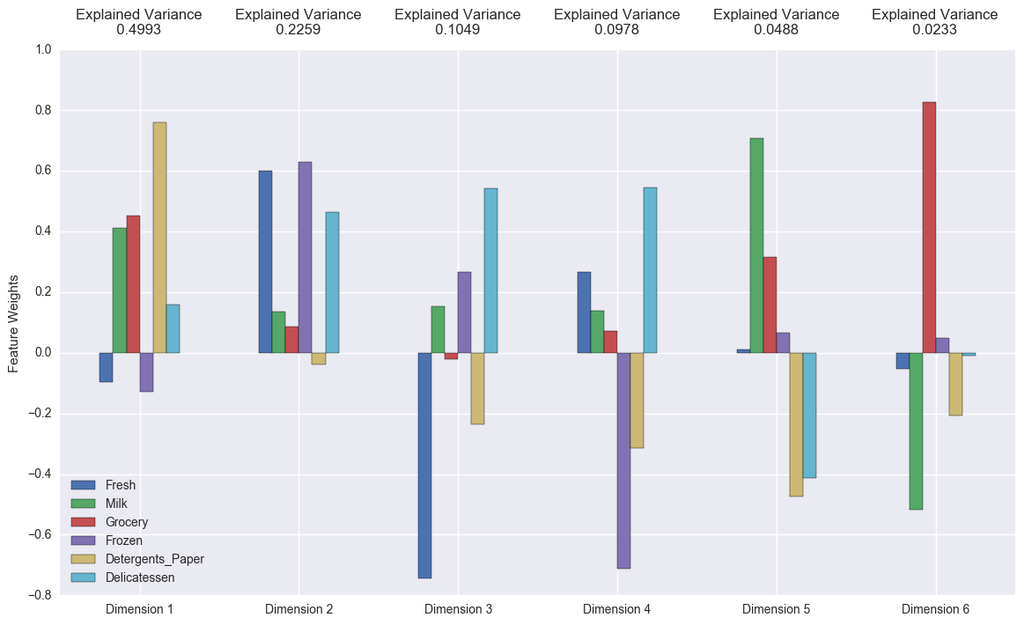

```python
# TODO: Apply PCA by fitting the good data with the same number of dimensions as features
from sklearn.decomposition import PCA
pca = PCA(n_components=good_data.shape[1])
pca.fit(good_data)

# TODO: Transform the sample log-data using the PCA fit above
pca_samples = pca.transform(log_samples)
print "pca_samples:::::\n", pca_samples

# Generate PCA results plot
pca_results = vs.pca_results(good_data, pca)
```

### Question 5

*How much variance in the data is explained* *in total* *by the first and second principal component? What about the first four principal components? Using the visualization provided above, discuss what the first four dimensions best represent in terms of customer spending.*  
**Hint:** A positive increase in a specific dimension corresponds with an *increase* of the *positive-weighted* features and a *decrease* of the *negative-weighted* features. The rate of increase or decrease is based on the indivdual feature weights.

```python
#reviewer2 taught the trick:
np.cumsum(pca.explained_variance_ratio_)
```

```
array([ 0.49930484,  0.7252529 ,  0.83013599,  0.92795361,  0.9767447 ,  1.        ])
```

**ORIGINAL Answer:**

In Dimension 1, Degergents_Paper and Grocery/milk are correlated.  
In Dimension 2, Frozen and Fresh/Delocatessen are correlated.  
In Dimension 3, Fresh(-ve) and Delicatessen are correlated.  
In Dimension 4, Frozen(-ve) and Delicatessen are correlated.

**#Reviewer2 suggests to add:**

- How each component relates to customer spending. Therefore for each component what are the prevalent features in each(nice job!).
- What does a high value in the component represent? What type of customer?
- PCA deals with the variance(spread) of the data and the correlation between features.
- Note in the third and forth components, a principal component with feature weights that have opposite directions can reveal how customers buy more in one category while they buy less in the other category
- Check out this visual and links
- https://onlinecourses.science.psu.edu/stat505/node/54
- http://webspace.ship.edu/pgmarr/Geo441/Lectures/Lec%2017%20-%20Principal%20Component%20Analysis.pdf

**REVISED Answer:**

Q:Discuss what the first four dimensions best represent in terms of customer spending.

First principal component(PC) explains variance in the data 0.50, second PC explains 0.23, therefore, 0.50+0.23= 0.73 in total. First 4 PC explains 0.50+0.23+0.1+0.1=0.93.

In Dimension 1, *Degergents_Paper/Grocery/milk* capture the highest variance, in other words, they are prevalent features and correlated. They can be considered as one segment altogether. This can be named as Segment 0.

In Dimension 2, *Frozen/Fresh/Delocatessen* capture the highest variance and prevalent features and correlated. They can be considered as another segment that are not related to the first dimension/segment(Segment 0). This can be named as Segment 1 altogether.

In Dimension 3, it captures only 0.1 variance, therefore, it may not be significantly meaningful but, Fresh has the greatest negative weight and Delicatessen has the greatest positive weight. One who buys Fresh more would buy Delicatessen less. *Delicatessen* may be considered as Segment 2.

In Dimension 4, it captures only 0.1 variance, therefore, it may not be significantly meaningful but, Frozen have negative weight and Delicatessen has positive weight. One who buys Frozen more would buy Delicatessen less.

**#Reviewer3 pointed**

Excellent work reporting the cumulative variance, but the discussion can be adjusted slightly to say that the dimensions represent **patterns of spending** in the categories, rather than actual customers (or segments of customers) — these patterns of spending can both follow AND go against the direction of the category weights.

With PCA, we could actually reverse the signs of the category weights and still be capturing the variance in the data.:

http://stats.stackexchange.com/questions/88880/does-the-sign-of-scores-or-of-loadings-in-pca-or-fa-have-a-meaning-may-i-revers

**REVISED Answer based on Reviewer3 comment :**

The first principal component is made up of large positive weights in *Detergents_Paper, Grocery & Milk*. It also correlates with a decrease in *Fresh and Frozen*. This pattern might represent spending in household staples products that are purchased together. The first component shows that we have a lot of variance in customers who purchase *Milk, Grocery & Detergents_Paper* — customers with HIGHER values in the first component (e.g., Retailers) purchase a lot of these 3 categories, while those with LOWER values in the component (e.g., Restaurants) purchase very little.

The 2nd principal component is made up of large positive weights in *Fresh, Frozen, Delicatessen*. It also correlates with a decrease in *Detergents_Paper*. This pattern might represent spending in Hotal/Restaurant/Cafe that are purchased together.

The 3rd principal component is made up of Fresh with the greatest negative weight and Delicatessen with the greatest positive weight. One who buys Fresh more would buy Delicatessen less. This pattern suggests *Delicatessen* may be considered as Segment 2 aside from Fresh.

The 4th principal component is made up of Frozen with negative weight and Delicatessen with positive weight. One who buys Frozen more would buy Delicatessen less. This pattern suggests *Delicatessen* may be considered as Segment 2 aside from Frozen.

**Reviewer4 added:**

Principal Component Analysis Explained Visually  
http://setosa.io/ev/principal-component-analysis/

PCA tutorial  
https://algobeans.com/2016/06/15/principal-component-analysis-tutorial/

### Observation

Run the code below to see how the log-transformed sample data has changed after having a PCA transformation applied to it in six dimensions. Observe the numerical value for the first four dimensions of the sample points. Consider if this is consistent with your initial interpretation of the sample points.

```python
# Display sample log-data after having a PCA transformation applied
display(pd.DataFrame(np.round(pca_samples, 4), columns = pca_results.index.values))
```

|  | Dimension 1 | Dimension 2 | Dimension 3 | Dimension 4 | Dimension 5 | Dimension 6 |
| --- | --- | --- | --- | --- | --- | --- |
| 0 | 1.7793 | -0.6604 | -0.8247 | 1.6580 | 0.0903 | -0.4808 |
| 1 | 1.8820 | 0.4617 | 0.2764 | 0.1055 | 0.0958 | -0.2093 |
| 2 | 2.1793 | 0.5069 | 0.8243 | -1.0031 | -0.4516 | 0.3107 |

```python
display(log_samples)
```

|  | Fresh | Milk | Grocery | Frozen | Detergents_Paper | Delicatessen |
| --- | --- | --- | --- | --- | --- | --- |
| 0 | 9.446913 | 9.175335 | 8.930759 | 5.365976 | 7.891331 | 7.198931 |
| 1 | 8.861775 | 9.191158 | 9.166179 | 7.474205 | 8.099554 | 7.482119 |
| 2 | 8.121480 | 8.594710 | 9.470703 | 8.389360 | 8.695674 | 7.463937 |

Log-transformed sample data has changed after having a PCA transformation applied to it in six dimensions.

It is observed that the numerical values changed for the first four dimensions of the sample points. It is consistent with your initial interpretation, strong correlation between Degergents_Paper and Grocery,etc.

### Implementation: Dimensionality Reduction

When using principal component analysis, one of the main goals is to reduce the dimensionality of the data — in effect, reducing the complexity of the problem. Dimensionality reduction comes at a cost: Fewer dimensions used implies less of the total variance in the data is being explained. Because of this, the *cumulative explained variance ratio* is extremely important for knowing how many dimensions are necessary for the problem. Additionally, if a signifiant amount of variance is explained by only two or three dimensions, the reduced data can be visualized afterwards.

In the code block below, you will need to implement the following:

- Assign the results of fitting PCA in two dimensions with `good_data` to `pca`.
- Apply a PCA transformation of `good_data` using `pca.transform`, and assign the results to `reduced_data`.
- Apply a PCA transformation of the sample log-data `log_samples` using `pca.transform`, and assign the results to `pca_samples`.

```python
# TODO: Apply PCA by fitting the good data with only two dimensions
pca = PCA(n_components=2)
pca=pca.fit(good_data)
print "pca_after fit:", pca

# TODO: Transform the good data using the PCA fit above
reduced_data = pca.transform(good_data)

# TODO: Transform the sample log-data using the PCA fit above
pca_samples = pca.transform(log_samples)


# Create a DataFrame for the reduced data
reduced_data = pd.DataFrame(reduced_data, columns = ['Dimension 1', 'Dimension 2'])
```

[output not shown]

[output not shown]

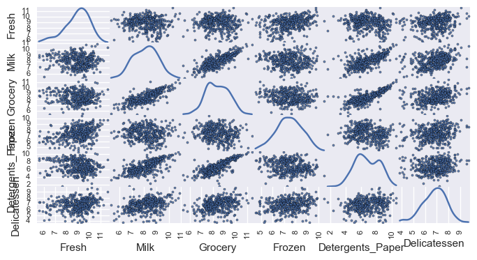

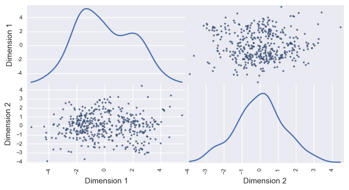

```python
#Reviewer3 added

#Reading on dimentionality reduction:
#    https://sebastianraschka.com/faq/docs/dimensionality-reduction.html


#If we view a scatter matrix of the reduced data, we can see 2 humps in the 1st Dimension
#that seem to indicate the presence of 2 distinct groups within the distribution...
#https://en.wikipedia.org/wiki/Multimodal_distribution


#Produce a scatter matrix for original data after removing outliers
pd.scatter_matrix(good_data, alpha = 0.8, figsize = (8,4), diagonal = 'kde');


# Produce a scatter matrix for pca reduced data
pd.scatter_matrix(reduced_data, alpha = 0.8, figsize = (8,4), diagonal = 'kde');
```

### Observation

Run the code below to see how the log-transformed sample data has changed after having a PCA transformation applied to it using only two dimensions. Observe how the values for the first two dimensions remains unchanged when compared to a PCA transformation in six dimensions.

```python
# Display sample log-data after applying PCA transformation in two dimensions
display(pd.DataFrame(np.round(pca_samples, 4), columns = ['Dimension 1', 'Dimension 2']))
```

|  | Dimension 1 | Dimension 2 |
| --- | --- | --- |
| 0 | 1.7793 | -0.6604 |
| 1 | 1.8820 | 0.4617 |
| 2 | 2.1793 | 0.5069 |

The first two dimensions didn't change when all features were used vs. when only 2 dimensions were used.

## Visualizing a Biplot

A biplot is a scatterplot where each data point is represented by its scores along the principal components. The axes are the principal components (in this case `Dimension 1` and `Dimension 2`). In addition, the biplot shows the projection of the original features along the components. A biplot can help us interpret the reduced dimensions of the data, and discover relationships between the principal components and original features.

Run the code cell below to produce a biplot of the reduced-dimension data.

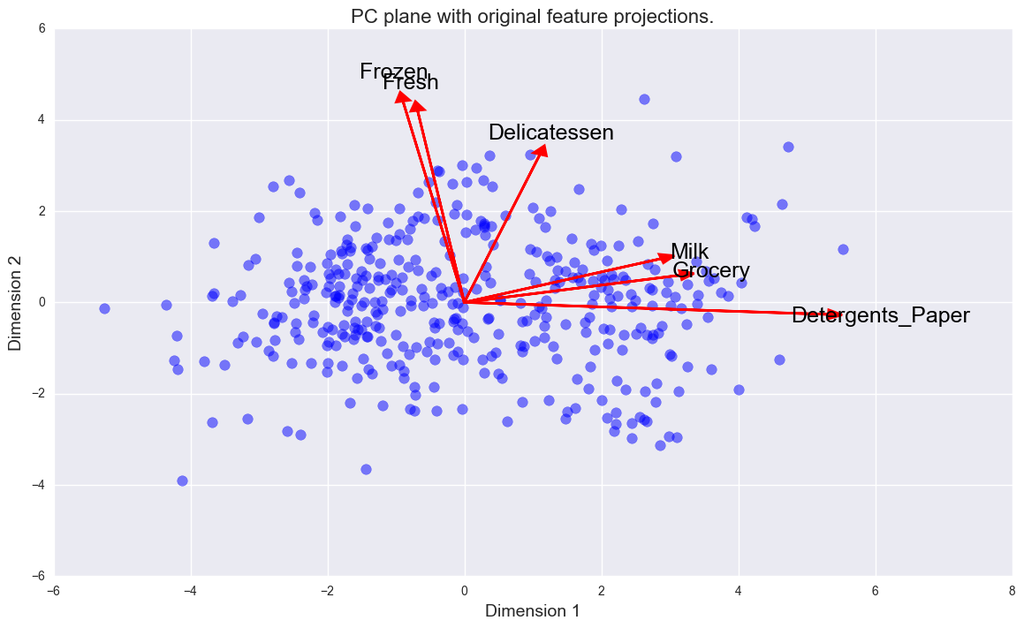

```python
# Create a biplot
vs.biplot(good_data, reduced_data, pca)
```

### Observation

Once we have the original feature projections (in red), it is easier to interpret the relative position of each data point in the scatterplot. For instance, a point the lower right corner of the figure will likely correspond to a customer that spends a lot on `'Milk'`, `'Grocery'` and `'Detergents_Paper'`, but not so much on the other product categories.

From the biplot, which of the original features are most strongly correlated with the first component? What about those that are associated with the second component? Do these observations agree with the pca_results plot you obtained earlier?

**Answer:**

These opservations agree with the pca_results plot in where shows the Dimension 1 has Detergents_Paper with the highest weight, Grocery, Milk are the next while Dimension 2 has Frozen and Gresh are highly weighted, and Delicatessen the next.

## Clustering

In this section, you will choose to use either a K-Means clustering algorithm or a Gaussian Mixture Model clustering algorithm to identify the various customer segments hidden in the data. You will then recover specific data points from the clusters to understand their significance by transforming them back into their original dimension and scale.

### Question 6

*What are the advantages to using a K-Means clustering algorithm? What are the advantages to using a Gaussian Mixture Model clustering algorithm? Given your observations about the wholesale customer data so far, which of the two algorithms will you use and why?*

**Answer:**

Reference: https://www.quora.com/What-is-the-difference-between-K-means-and-the-mixture-model-of-Gaussian

- **K-Means clustering algorithm:**
  - K means starts with the assumption that a given data point belongs to one cluster. Choose a data point. At a given point in the algorithm, we are certain that a point belongs to a red cluster. In the next iteration, we might revise that belief, and be certain that it belongs to the green cluster. However, in each iteration, we are absolutely certain as to which cluster the point belongs to. This is the "hard assignment".
  - Much faster and much more scalable.(#Reviewer2 added)
- **Gaussian Mixture Model(GMM) clustering algorithm:**  
  http://scikit-learn.org/stable/modules/generated/sklearn.mixture.GaussianMixture.html#sklearn.mixture.GaussianMixture
  - This algorithm takes probability which cluster a given point would belong to as "soft assignment". The Mixture of Gaussian model helps us to express this uncertainty. It starts with some prior belief about how certain we are about each point's cluster assignments. As it goes on, it revises those beliefs. But it incorporates the degree of uncertainty we have about our assignment.
  - Slower since it has to incorporate information about the distributions of the data, thus it has to deal with the co-variance, mean, variance, and prior probabilities of the data, and also has to assign probabilities to belonging to each clusters.(#Reviewer2 added)

Given the observations about the wholesale customer data that many datapoints can be in between many clusters (or mixture of features), not as sharply divided by any certain boundaries, it would make the most sense if Gaussian Mixture model would work better.

**#Reviewer4 added**

density based clustering DBSCAN  
http://scikit-learn.org/stable/modules/clustering.html#dbscan

- A big drawback with KMeans is that it assumes the groups are spherical (globular) shapes that are symmetrical, which don't always occur with real data. http://stats.stackexchange.com/questions/133656/how-to-understand-the-drawbacks-of-k-means
- GMM assumes the groups to be elliptical. http://stackoverflow.com/questions/26019584/understanding-concept-of-gaussian-mixture-models

[figure not shown]

### Implementation: Creating Clusters

Depending on the problem, the number of clusters that you expect to be in the data may already be known. When the number of clusters is not known *a priori*, there is no guarantee that a given number of clusters best segments the data, since it is unclear what structure exists in the data — if any. However, we can quantify the "goodness" of a clustering by calculating each data point's *silhouette coefficient*. The [silhouette coefficient](http://scikit-learn.org/stable/modules/generated/sklearn.metrics.silhouette_score.html) for a data point measures how similar it is to its assigned cluster from -1 (dissimilar) to 1 (similar). Calculating the *mean* silhouette coefficient provides for a simple scoring method of a given clustering.

In the code block below, you will need to implement the following:

- Fit a clustering algorithm to the `reduced_data` and assign it to `clusterer`.
- Predict the cluster for each data point in `reduced_data` using `clusterer.predict` and assign them to `preds`.
- Find the cluster centers using the algorithm's respective attribute and assign them to `centers`.
- Predict the cluster for each sample data point in `pca_samples` and assign them `sample_preds`.
- Import `sklearn.metrics.silhouette_score` and calculate the silhouette score of `reduced_data` against `preds`.
  - Assign the silhouette score to `score` and print the result.

```python
# TODO: Apply your clustering algorithm of choice to the reduced data
#http://scikit-learn.org/stable/auto_examples/mixture/plot_gmm_selection.html#sphx-glr-auto-examples-mixture-plot-gmm-selection-py

'''
#example of Kmeans
from sklearn.cluster import KMeans
kmeans_model = KMeans(n_clusters=3, random_state=1).fit(X)
labels = kmeans_model.labels_
metrics.silhouette_score(X, labels, metric='euclidean')
kmeans.cluster_centers_
'''

from sklearn import mixture
from sklearn import metrics

#Reviewer2 suggests to do programmatically for each n_components.
for k in range(2,5):
    clusterer = mixture.GaussianMixture(n_components=k)
    clusterer=clusterer.fit(reduced_data)
    #print "clusterer:", clusterer

# TODO: Predict the cluster for each data point
    preds = clusterer.predict(reduced_data)
    #print "preds:",preds,preds.shape
#'GaussianMixture' object has no attribute 'labels_'(clusterer.labels_)

# TODO: Find the cluster centers: gmm doesnt have a specific atttribute to calculate clusterer.cluster_centers_
    centers = clusterer.means_

# TODO: Predict the cluster for each transformed sample data point
    sample_preds = clusterer.predict(pca_samples)
    print "pca_samples pred:", sample_preds

# TODO: Calculate the mean silhouette coefficient for the number of clusters chosen
#http://scikit-learn.org/stable/modules/generated/sklearn.metrics.silhouette_score.html
    score = metrics.silhouette_score(reduced_data, preds, metric='euclidean') #preds is label
    print "n_components=",k, ",silhouette score:",score
```

```
pca_samples pred: [0 0 0]
n_components= 2 ,silhouette score: 0.446753526945
pca_samples pred: [2 2 2]
n_components= 3 ,silhouette score: 0.361193625039
pca_samples pred: [2 2 2]
n_components= 4 ,silhouette score: 0.299093443086
```

### Question 7

*Report the silhouette score for several cluster numbers you tried. Of these, which number of clusters has the best silhouette score?*

**Answer:**

And when two clusters are chosen, the silhouette score is the highest.

**Reviewer4 added:**

Note: choosing number of clusters It can often be ambiguous determining whether silhouette score, or any other measure of clustering performance, gives a definitive answer to the "correct" number of clusters in a dataset.

For example, Silhouette score is based on [Euclidean distance](http://scikit-learn.org/stable/modules/generated/sklearn.metrics.pairwise.euclidean_distances.html), which is the metric used to form clusters in K-Means — this could produce scores that are well-suited to K-Means but not necessarily to GMM.

While using [GMM](http://scikit-learn.org/stable/auto_examples/mixture/plot_gmm_selection.html) you can also look at the Bayesian Information Criterion ([BIC](https://en.wikipedia.org/wiki/Bayesian_information_criterion)) or the Akaike information criterion ([AIC](https://en.wikipedia.org/wiki/Akaike_information_criterion)) for finding the optimal number of clusters.

```python
# Look at BIC
print "clusters BIC: {}".format(clusterer.bic(reduced_data))

# Look at AIC
print "clusters AIC: {}".format(clusterer.aic(reduced_data))
```

```
clusters BIC: 3075.26833092
clusters AIC: 3031.41735886
```

### Cluster Visualization

Once you've chosen the optimal number of clusters for your clustering algorithm using the scoring metric above, you can now visualize the results by executing the code block below. Note that, for experimentation purposes, you are welcome to adjust the number of clusters for your clustering algorithm to see various visualizations. The final visualization provided should, however, correspond with the optimal number of clusters.

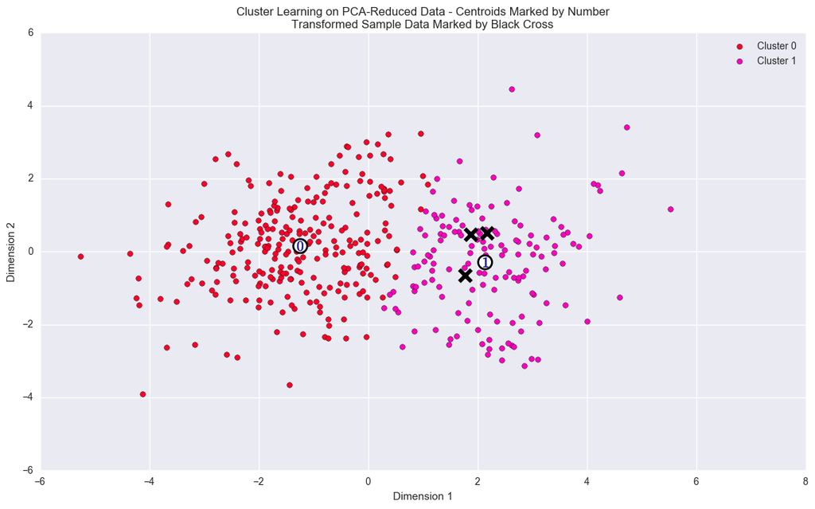

```python
# Display the results of the clustering from implementation

#with optimal number of cluster, re-run:
k=2
clusterer = mixture.GaussianMixture(n_components=k)
clusterer=clusterer.fit(reduced_data)
preds = clusterer.predict(reduced_data)
centers = clusterer.means_
sample_preds = clusterer.predict(pca_samples)
score = metrics.silhouette_score(reduced_data, preds, metric='euclidean') #preds is label

vs.cluster_results(reduced_data, preds, centers, pca_samples)
```

### Implementation: Data Recovery

Each cluster present in the visualization above has a central point. These centers (or means) are not specifically data points from the data, but rather the *averages* of all the data points predicted in the respective clusters. For the problem of creating customer segments, a cluster's center point corresponds to *the average customer of that segment*. Since the data is currently reduced in dimension and scaled by a logarithm, we can recover the representative customer spending from these data points by applying the inverse transformations.

In the code block below, you will need to implement the following:

- Apply the inverse transform to `centers` using `pca.inverse_transform` and assign the new centers to `log_centers`.
- Apply the inverse function of `np.log` to `log_centers` using `np.exp` and assign the true centers to `true_centers`.

```python
print "Initial centers:"
display(centers)

# TODO: Inverse transform the centers
log_centers = pca.inverse_transform(centers)

# TODO: Exponentiate the centers
true_centers = np.exp(log_centers)

# Display the true centers
segments = ['Segment {}'.format(i) for i in range(0,len(centers))]
true_centers = pd.DataFrame(np.round(true_centers), columns = data.keys())
true_centers.index = segments
display(true_centers)
```

```
Initial centers:
```

```
array([[-1.2422204 ,  0.16820922],
       [ 2.1349413 , -0.28909267]])
```

|  | Fresh | Milk | Grocery | Frozen | Detergents_Paper | Delicatessen |
| --- | --- | --- | --- | --- | --- | --- |
| Segment 0 | 9468.0 | 2067.0 | 2624.0 | 2196.0 | 343.0 | 799.0 |
| Segment 1 | 5174.0 | 7776.0 | 11581.0 | 1068.0 | 4536.0 | 1101.0 |

### Question 8

Consider the total purchase cost of each product category for the representative data points above, and reference the statistical description of the dataset at the beginning of this project. *What set of establishments could each of the customer segments represent?*  
**Hint:** A customer who is assigned to `'Cluster X'` should best identify with the establishments represented by the feature set of `'Segment X'`.

**ORIGINAL Answer:**

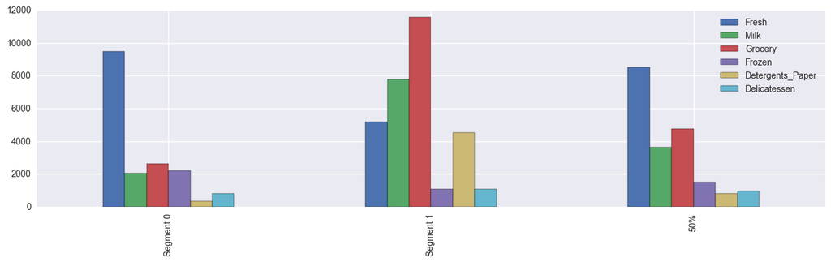

```python
#Reviewer2 suggests to look median and cluster centroid
true_centers = true_centers.append(data.describe().ix['50%'])
true_centers.plot(kind = 'bar', figsize = (16, 4))
```

**REVISED Answer:**

Q: What set of establishments could each of the customer segments represent? Q: Explicitly refer the descriptive stats of each feature for justification for each cluster centroid. Thus a good idea here would be to compare each product to the mean / median / quartiles.

In Cluster/Segment 0, center of cluster for Fresh is higher than entire data median. This means, Fresh is more purchased in this cluster than the entire customer median. Customer Cluster/Segment 0 represents ones who purchase Fresh more.

in Cluster/Segment 1, center of cluster for Grocery/Milk is higher than data median. This means, Grocery/Milk is more purchased than the entire customer median. Customer Cluster/Segment 1 represents ones who purchase Grocery/Milk more.

# Reviewer3 added:

Great discussion of the segment centers with reference to the category spending stats — **the clusters appear to be generally split on spending in the 1st pca dimension**, with the cluster centers largely characterized by having above or below median spending in *Milk, Grocery, Detergents_Paper*.

### Question 9

*For each sample point, which customer segment from* *Question 8* *best represents it? Are the predictions for each sample point consistent with this?*

Run the code block below to find which cluster each sample point is predicted to be.

```
Sample point 0 predicted to be in Cluster 1
Sample point 1 predicted to be in Cluster 1
Sample point 2 predicted to be in Cluster 1
```

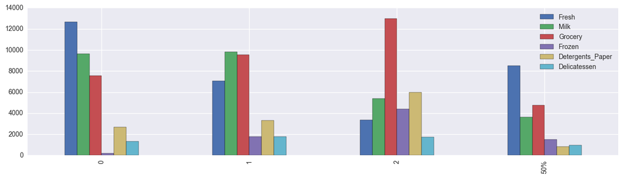

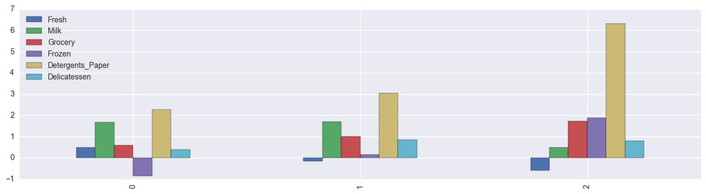

```python
#Reviewer 2 suggests to compare sample points with stats.
samples_withmedian = samples.append(data.describe().ix['50%'])
samples_withmedian.plot(kind = 'bar', figsize = (16, 4))
delta_samples_median_in_percentage=(samples-data.describe().ix['50%'])/data.describe().ix['50%']
delta_samples_median_in_percentage.plot(kind='bar', figsize=(16,4))

# Display the predictions
for i, pred in enumerate(sample_preds):
    print "Sample point", i, "predicted to be in Cluster", pred
```

## Conclusion

In this final section, you will investigate ways that you can make use of the clustered data. First, you will consider how the different groups of customers, the *customer segments*, may be affected differently by a specific delivery scheme. Next, you will consider how giving a label to each customer (which *segment* that customer belongs to) can provide for additional features about the customer data. Finally, you will compare the *customer segments* to a hidden variable present in the data, to see whether the clustering identified certain relationships.

### Question 10

Companies will often run [A/B tests](https://en.wikipedia.org/wiki/A/B_testing) when making small changes to their products or services to determine whether making that change will affect its customers positively or negatively. The wholesale distributor is considering changing its delivery service from currently 5 days a week to 3 days a week. However, the distributor will only make this change in delivery service for customers that react positively. *How can the wholesale distributor use the customer segments to determine which customers, if any, would react positively to the change in delivery service?*  
**Hint:** Can we assume the change affects all customers equally? How can we determine which group of customers it affects the most?

**ORIGINAL Answer:**

Customer who belongs to grocery/milk or fresh may not want to reduce the frequency in delivery service. However, ones who mostly buys Detergents or any non-perishable items may positively react to the change.

**REVISED Answer:**

**Reviewer1 suggests to explain how an A/B test can be performed on customers after a change in the wholesale distributor’s service:**

With the given future change in delivery from 5 to 3 time a week, A/B test can be implemented on customer segments with perishiable and non-perishable item. Customer segments with perishable may not react positively, and customer segments without perishable may react positively.

https://en.wikipedia.org/wiki/A/B_testing https://www.optimizely.com/ab-testing/

**Reviewer2 suggests to comment on how to implement A/B test,**

Q: How to set control / test groups and a experimental variable  
A: Control group would be 5 times a week delivery, test group gets 3 times a week delivery.

Q: Can we use all of the segments together or do we need to run separate A/B tests on each independently?  
A: Per segment, we run seperate A/B tests for control group vs. test group. We can not run A/B test for all of the segments together. The segment that has more score in test group(3 times a a week) is actually decided to be changed to 3 times a week delivery. The segment that has poor score in test group is NOT decided to change from 5 times a week delivery.

https://en.wikipedia.org/wiki/A/B_testing#Segmentation_and_targeting https://vwo.com/ab-testing/

**Reviewer3 added

A/B testing 1. Split some Segment 0 customers into "A/control" and "B/treatment" groups to detect a difference  
A/B testing 2. Split some Segment 1 customers into "A/control" and "B/treatment" groups to detect a difference

https://en.wikipedia.org/wiki/A/B_testing#Segmentation_and_targeting

When A/B testing shouldn't be trusted:  
https://www.quora.com/When-should-A-B-testing-not-be-trusted-to-make-decisions/answer/Edwin-Chen-1  
Pitfalls of A/B testing:  
https://www.oreilly.com/ideas/evaluating-machine-learning-models/page/6/the-pitfalls-of-a-b-testing  
Great Data Skeptic podcast on "p-hacking" and other shady practices to watch out for in A/B tests  
http://dataskeptic.com/blog/episodes/2016/multiple-comparisons-and-conversion-optimization

### Question 11

Additional structure is derived from originally unlabeled data when using clustering techniques. Since each customer has a *customer segment* it best identifies with (depending on the clustering algorithm applied), we can consider *'customer segment'* as an **engineered feature** for the data. Assume the wholesale distributor recently acquired ten new customers and each provided estimates for anticipated annual spending of each product category. Knowing these estimates, the wholesale distributor wants to classify each new customer to a *customer segment* to determine the most appropriate delivery service.  
*How can the wholesale distributor label the new customers using only their estimated product spending and the* *customer segment* *data?*  
**Hint:** A supervised learner could be used to train on the original customers. What would be the target variable?

**Answer:**

We can make a supervised learning by using the original customers' predicted segment as an input feature(engineering feature) as in training set, and predicting a new custermer's segment(target).

Reviewer1 suggests to read: https://en.wikipedia.org/wiki/Feature_engineering

Reviewer2 suggests to read: https://www.kaggle.com/c/digit-recognizer

```python
#Reviewer4 added : For a supervised learning analysis of the cluster labels,
#we can get pretty good results by using KNN.


from sklearn.cross_validation import train_test_split
from sklearn.neighbors import KNeighborsClassifier

X_train, X_test, y_train, y_test = train_test_split(reduced_data, preds, test_size=0.25, random_state=42)

clf = KNeighborsClassifier(weights='distance')
clf.fit(X_train, y_train)

# Report the score for training and testing
print "Training accuracy = {:.4f}".format(clf.score(X_train, y_train))
print "Testing accuracy = {:.4f}".format(clf.score(X_test, y_test))
```

```
Training accuracy = 1.0000
Testing accuracy = 0.9900
```

**NOTE**  
[KNeighborsClassifier](http://scikit-learn.org/stable/modules/generated/sklearn.neighbors.KNeighborsClassifier.html) and [KMeans](http://scikit-learn.org/stable/modules/generated/sklearn.cluster.KMeans.html) are different.

KNeighborsClassifier is for Classifier implementing the k-nearest neighbors vote:

```
sklearn.neighbors.KNeighborsClassifier(n_neighbors=5, weights='uniform', algorithm='auto', leaf_size=30, p=2, metric='minkowski', metric_params=None, n_jobs=1, **kwargs)
```

Kmeans is for K-Means clustering:

```
sklearn.cluster.KMeans(n_clusters=8, init='k-means++', n_init=10, max_iter=300, tol=0.0001, precompute_distances='auto', verbose=0, random_state=None, copy_x=True, n_jobs=1, algorithm='auto')[source]
```

### Visualizing Underlying Distributions

At the beginning of this project, it was discussed that the `'Channel'` and `'Region'` features would be excluded from the dataset so that the customer product categories were emphasized in the analysis. By reintroducing the `'Channel'` feature to the dataset, an interesting structure emerges when considering the same PCA dimensionality reduction applied earlier to the original dataset.

Run the code block below to see how each data point is labeled either `'HoReCa'` (Hotel/Restaurant/Cafe) or `'Retail'` the reduced space. In addition, you will find the sample points are circled in the plot, which will identify their labeling.

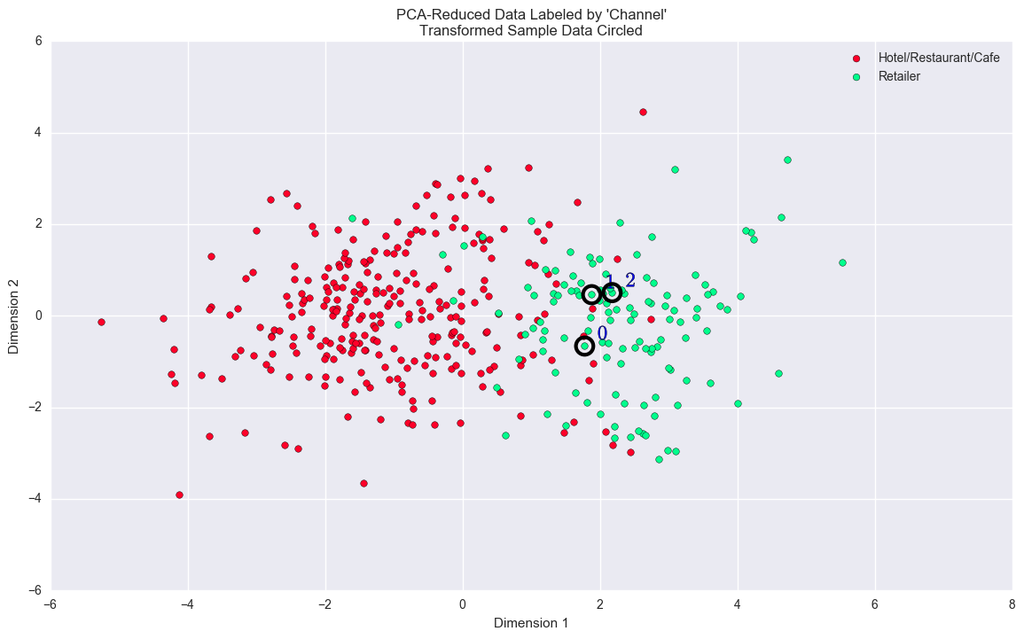

```python
# Display the clustering results based on 'Channel' data
vs.channel_results(reduced_data, outliers.transpose().index, pca_samples)
```

### Question 12

*How well does the clustering algorithm and number of clusters you've chosen compare to this underlying distribution of Hotel/Restaurant/Cafe customers to Retailer customers? Are there customer segments that would be classified as purely 'Retailers' or 'Hotels/Restaurants/Cafes' by this distribution? Would you consider these classifications as consistent with your previous definition of the customer segments?*

**Answer:**

Clustering algorithm seems to be pretty well consistent with the channel/the definition of customer segments.

```python
#Reviewer4 added comments:

#With soft clustering we can also take a look at the predicted probabilities of the cluster
#assignments... (thanks GMM!)

# look at just the 3 sample points
samples_proba = clusterer.predict_proba(pca_samples)

for i, pred in enumerate(sample_preds):
    print "Sample point", i, "predicted to be in Cluster {} ({:.2f}%)".format(pred, samples_proba[i][pred]*100)
```

```
Sample point 0 predicted to be in Cluster 1 (96.27%)
Sample point 1 predicted to be in Cluster 1 (92.64%)
Sample point 2 predicted to be in Cluster 1 (96.10%)
```

> **Note**: Once you have completed all of the code implementations and successfully answered each question above, you may finalize your work by exporting the iPython Notebook as an HTML document. You can do this by using the menu above and navigating to  
> **File -> Download as -> HTML (.html)**. Include the finished document along with this notebook as your submission.